# Lecture 1: Why Study Econometrics?

From Economic Questions to Credible Answers

> **Anchor question:** Should UiT conclude that requiring students to attend econometrics lectures would improve their grades?

This lecture introduces econometrics as a way of moving from an economic question to a conclusion that is justified by evidence. The emphasis is not on memorising definitions or learning R syntax. It is on deciding **what a model tells us, what it does not tell us, and what could make our conclusion wrong**.

**Textbook connection:** *Principles of Econometrics*, 5th ed., Chapter 1 — especially §§1.1, 1.2, 1.3, 1.3.1, 1.4 and 1.6.

## Learning outcomes

After this lecture, you should be able to:

1. **Translate** an economic question into a simple econometric model and explain what belongs in the systematic component and what may end up in the error term.
2. **Distinguish** a predictive relationship from a causal claim and identify plausible alternative explanations for an observed association.
3. **Critique** an empirical conclusion — including one produced by an LLM — by asking whether the data, model and research design justify the claim.

**ImportantMust understand**

- Econometrics starts with an economic question, not with `lm()`.
- Economic models simplify reality; econometric models add parameters and an error term.
- A relationship useful for **prediction** is not automatically a **causal effect**.
- The way data were generated matters for what we can conclude.
- An econometric result is an argument requiring justification, not merely numerical output.

**NoteUseful reference material — do not memorise**

- Experimental, quasi-experimental and nonexperimental data (§1.4)
- Cross-sectional, time-series and panel data (§1.5)
- Micro/macro, stock/flow, quantitative/qualitative data
- The complete research-process checklist in §1.6
- Data repositories and research-paper structure in §§1.7–1.8

## Pre-class / reference reading

**Read:** §§1.1, 1.3.1 and 1.6.  
**Skim:** §§1.4–1.5.  
**Reference only:** §§1.7–1.8.

# 0. Retrieval and connection

Suppose economic theory suggests

$$Q^d = f(P, INC).$$

### Retrieval question

> If the price of a product is higher in markets where sales are lower, have we demonstrated that lowering the price will increase sales by a particular amount?

**TipExpected answer**

No. Economic theory suggests a relationship and perhaps a sign, but we do not yet know **how much**, markets may differ in other ways, observed prices were not necessarily assigned experimentally, and we have not yet specified a statistical model.

**Connection:** the gap between an economic relationship and what data allow us to conclude is where econometrics begins.

# 1. The hook

## The policy question

Imagine that you are the programme director. Students who miss more lectures appear to receive lower exam grades.

> **Should you introduce mandatory attendance?**

Before seeing any regression output, make a decision:

- **A.** Yes — clearly
- **B.** Probably yes
- **C.** Not enough evidence
- **D.** No — attendance clearly does not matter

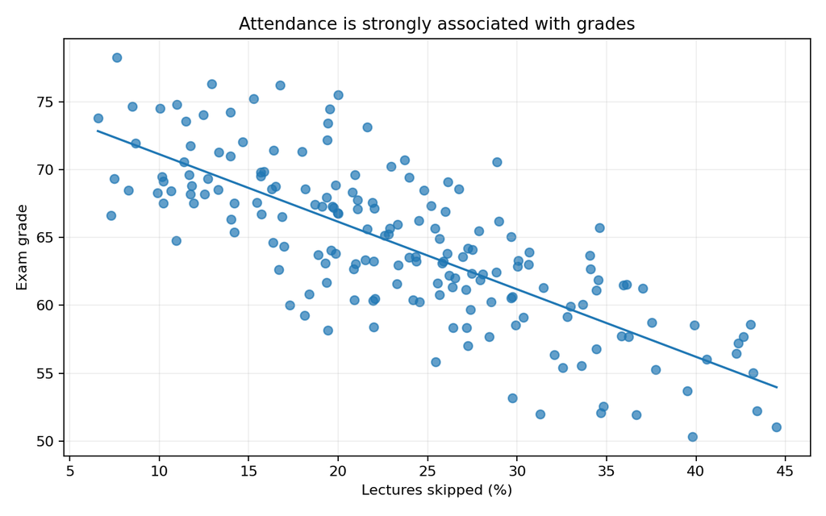

Now estimate the simplest possible model:

$$GRADE_i = \beta_1 + \beta_2 SKIP_i + e_i.$$

The synthetic data give approximately

$$\widehat{GRADE}=76.10-0.497\,SKIP,
\qquad R^2=0.586.$$

A student who skips **10 percentage points more lectures** is predicted to score about

$$10(-0.497)\approx -5.0$$

grade points lower.

### Vote again

> Does this strengthen the case for mandatory attendance?

Do not answer the policy question yet.

# 2. Minimal theory

## 2.1 From an economic model to an econometric model

A richer economic model might be

$$GRADE=f(SKIP,STUDY,MOTIVATION,JOB,\ldots).$$

We cannot observe or include everything. Our first econometric model is therefore

$$GRADE_i=\beta_1+\beta_2SKIP_i+e_i.$$

### What is inside $e_i$?

Possible answers include:

- ability and prior knowledge;
- motivation;
- study effort;
- paid work and family commitments;
- health;
- measurement error;
- other unpredictable influences.

**ImportantKey idea**

The error term is **not just a mistake in the data**. It represents determinants of the outcome that are not explicitly represented in our systematic model, together with genuinely unpredictable variation.

## 2.2 What is $\beta_2$ supposed to answer?

There are at least two different questions.

### Prediction question

> Students who skip 10 percentage points more lectures tend to score how much lower?

Our first regression may answer this quite well.

### Causal question

> If we forced a particular student to attend 10 percentage points more lectures, how much would their grade improve?

That is a much stronger question.

$$\boxed{\text{Prediction} \neq \text{Causal effect}}$$

## 2.3 Why can prediction and causation differ?

```
                     motivation
                    /          \
                   v            v
             attendance -----> grade
                   ^
                study time

paid work --------> attendance
     \------------> grade
```

If highly motivated students both attend more often **and** perform better for other reasons, a simple attendance coefficient can reflect more than the effect of attendance itself.

**NoteYou do not need to know the formal solution yet**

Later in the course we will give problems like this names, assumptions, formulas and econometric solutions. Today the objective is simply to **recognise the problem before interpreting a coefficient**.

## 2.4 Where the data came from matters

> Would your causal interpretation be more credible if students had been randomly assigned to different attendance requirements?

Random assignment would change the comparison. With observational data, students decide whether to attend, and those decisions may be related to other determinants of grades.

# 3. Econometric lab

The data below are **synthetic** and designed specifically for this lecture. They are not real UiT student data.

## Lab 1 — Is attendance informative?

**Question:** Can lecture attendance help us predict exam performance?

**Prediction:** What sign should the coefficient on `skip` have?

**R action:**

**Show R code**

```r
m1 <- lm(grade ~ skip, data = students)
coef(m1)
```

```
(Intercept)        skip
 76.1034299  -0.4972959
```

**Show R code**

```r
summary(m1)$r.squared
```

```
[1] 0.5859168
```

**Result:**

$$\widehat{GRADE}=76.103-0.497\,SKIP,
\qquad R^2=0.586.$$

**Interpretation:** 10 percentage points more absence predicts approximately **5 points lower grade**.

**Decision:** Attendance is useful information for prediction. We have **not** yet established a causal effect.

## Lab 2 — Look behind the coefficient

**Question:** Are students who attend more also different in how much they study?

**Prediction:** Among students with higher absence, do you expect study hours to be higher, lower, or unrelated?

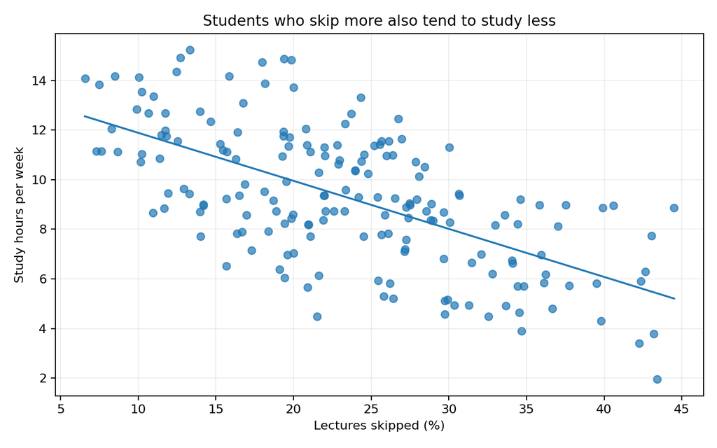

**R action:**

**Show R code**

```r
cor(students$skip, students$study)
```

```
[1] -0.6269108
```

**Result:**

$$cor(SKIP,STUDY)=-0.627.$$

**Interpretation:** Our original comparison was not between otherwise identical students who differed only in attendance. Students with greater absence also tend to study less.

**Decision:** The causal interpretation of the original $-0.497$ coefficient is now less credible.

## Lab 3 — Change the specification

**Question:** What is the attendance relationship among students with the same measured study time?

**Prediction:** Will the `skip` coefficient become more negative, less negative, or stay approximately the same?

**R action:**

**Show R code**

```r
m2 <- lm(grade ~ skip + study, data = students)
coef(m2)
```

```
(Intercept)        skip       study
 65.5831673  -0.3499736   0.7611523
```

**Result:**

$$\widehat{\beta}_{SKIP}=-0.350.$$

The coefficient has moved from

$$-0.497 \longrightarrow -0.350.$$

**Interpretation:** Part of the original attendance coefficient reflected systematic differences in study effort.

**Decision:** Model 1 and Model 2 answer different conditional questions. Neither coefficient should automatically be labelled “the truth.”

## Lab 4 — Deliberate failure: the plausible wrong conclusion

**Question:** Could the original result mainly reflect **who skips**, rather than only **what skipping does**?

Now include measured motivation and weekly paid-work hours.

**Prediction:** What should happen to the attendance coefficient?

**R action:**

**Show R code**

```r
m3 <- lm(
  grade ~ skip + study + motivation + job_hours,
  data = students
)
coef(m3)
```

```
(Intercept)        skip       study  motivation   job_hours
 64.9124288  -0.1475248   0.5276382   2.4207392  -0.1593759
```

**Result:**

$$\widehat{\beta}_{SKIP}=-0.148.$$

The coefficient path is therefore

$$\boxed{-0.497 \rightarrow -0.350 \rightarrow -0.148}.$$

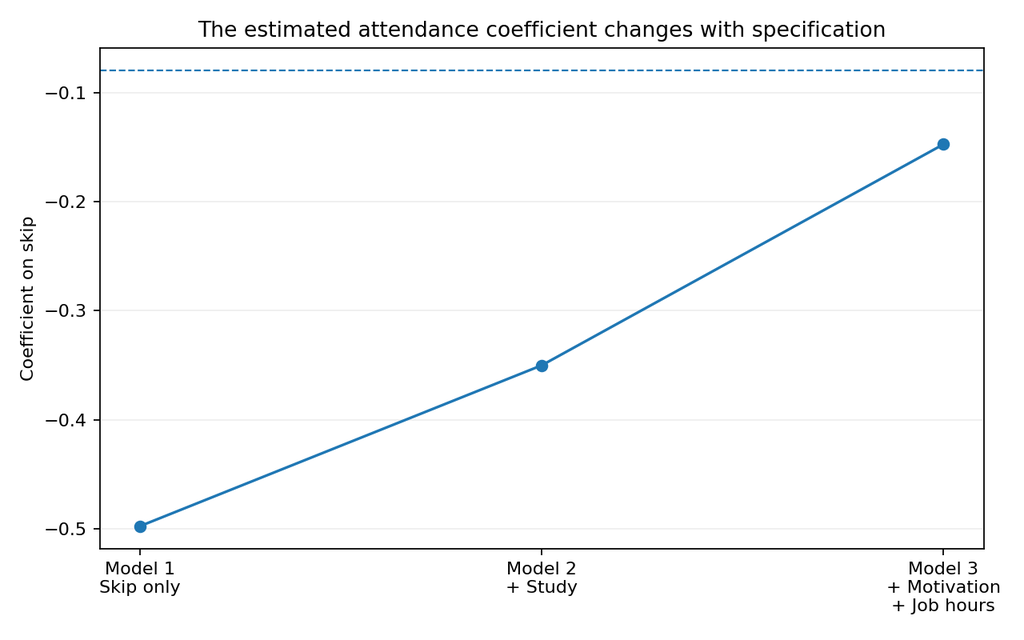

**Interpretation:** The naive model found a genuine association, but its simple causal interpretation badly exaggerated the direct attendance effect.

**WarningThe deliberate failure**

A technically correct regression gave a misleading substantive conclusion:

> “Ten percentage points more absence lowers grades by five points, therefore forcing attendance will raise grades by five points.”

The arithmetic is correct. The **causal interpretation is not justified**.

**NoteInstructor-only construction detail**

The synthetic data-generating process contains a direct effect of only $-0.08$ grade points per percentage point of absence. Even Model 3 estimates approximately $-0.148$ because an ability component remains deliberately unobserved. This ensures that “add controls until the coefficient becomes causal” is **not** the lesson.

## Lab 5 — Was Model 1 useless?

**Question:** If our only purpose were to identify students at risk of a low grade, should Model 1 be discarded?

No.

Model 1 still has

$$R^2=0.586,$$

and absence is genuinely informative about grades.

**ImportantSame variable, different purpose**

Attendance can be:

- highly useful for **prediction**;
- much less trustworthy for answering an **intervention question**.

A model can therefore be useful without supporting the causal interpretation we would like to give it.

### Return to the anchor

> **Could UiT use absence to identify students who may need help?**

Quite possibly.

> **Do these regressions demonstrate that compulsory attendance would raise grades by five points?**

No.

# Interactive sensitivity check

Move the slider to change the hypothetical increase in absence. The widget shows how much the three specifications would predict grades to change.

**Increase in lectures skipped:** 10 percentage points

*The widget changes the arithmetic, not the credibility of the causal interpretation.*

# 4. AI Audit

Give an LLM the following prompt.

```
We have observational data on 180 university students.

Model 1:
grade = 76.10 - 0.497 skip, R^2 = 0.586

Model 2, controlling for weekly study hours:
coefficient on skip = -0.350

Model 3, controlling for study hours, motivation and weekly paid-work hours:
coefficient on skip = -0.148

skip is the percentage of lectures missed.

The university is considering mandatory attendance.

Based on these results, should the university conclude that increasing
attendance will improve students' grades? Explain what the regressions show
and make a recommendation.
```

## Audit the answer — do not merely ask whether it is “correct”

Evaluate the response using five questions:

1. **What question did the AI answer?** Prediction or causation?
2. **Did it distinguish association from intervention?**
3. **Did it explain why the coefficient changes?**
4. **What remains unobserved?** Ability, prior achievement, health, engagement, other behaviour?
5. **Does its policy recommendation go beyond the evidence?**

## If the LLM gives a good answer

Use this follow-up:

```
Now make the strongest possible case that these results DO justify mandatory
attendance. Then make the strongest possible case that they DO NOT.
Finally, identify the single piece of additional evidence that would most help
distinguish between the two arguments.
```

The strongest additional evidence would involve credible exogenous variation in attendance — ideally random assignment or a defensible quasi-experimental design.

**TipCourse principle for AI**

The goal is not to make AI unusable or to catch it hallucinating. The task is to judge whether the **model, interpretation, assumptions and conclusion** are defensible.

# 5. Exit problem

A company estimates

$$\widehat{SALES}=120+8ADVERTISING,$$

where `ADVERTISING` is thousands of kroner spent weekly. Stores that advertise more also tend to be larger and located in busier areas.

A manager says:

> “If we give every store NOK 1,000 more advertising money, sales will increase by 8 units.”

Which response is best?

**A.** Correct — the coefficient is 8.  
**B.** Incorrect because advertising and sales have a positive relationship.  
**C.** The regression may predict sales, but the coefficient need not equal the causal effect of increasing advertising.  
**D.** We cannot learn anything from observational data.

**TipExpected answer: C**

The coefficient describes an observed relationship, but store characteristics associated with both advertising and sales may contribute to that relationship.

- **A** reveals automatic causal interpretation of a regression coefficient.
- **B** confuses positive association with evidence against causality.
- **D** overreacts: observational relationships can still be useful, especially for prediction.

# The Econometric Loop

Econometric work does not end when software produces a coefficient.

## 1 — ASK

> What are we trying to learn?

↓

## 2 — MODEL

> What economic mechanism could generate the outcome?

↓

## 3 — IDENTIFY

> What would have to be true for our estimate to answer the question?

↓

## 4 — ESTIMATE

> What does the data say?

↓

## 5 — CHALLENGE

> What else could explain the result?

↓

## 6 — CONCLUDE

> What does the evidence actually justify saying?

↓

## Repeat

**ImportantThe one sentence to remember**

**A regression coefficient is not an answer until you know what question the model can legitimately answer.**

# Assessment connection

Use a different setting from the lecture anchor.

## Remote work and wages

A labour-market study uses observational data on 2,000 employees:

$$\widehat{WAGE}=24.0+4.5REMOTE,$$

and

$$\widehat{WAGE}=18.2+1.2REMOTE+0.8EDUCATION+0.5EXPERIENCE.$$

`WAGE` is hourly wage in euros and `REMOTE = 1` for employees who work mainly from home.

## Part A — Closed-book / individual reasoning

### A1

Interpret the coefficient 4.5 in the first model.

**Tip**

Employees working mainly remotely have hourly wages predicted to be €4.50 higher on average than non-remote employees. This does **not** automatically mean that assigning a worker to remote work raises their wage by €4.50.

### A2

Why might the `REMOTE` coefficient fall from 4.5 to 1.2 after education and experience are included?

**Tip**

Remote and non-remote workers differ in education and experience, and those characteristics are also associated with wages. Part of the original wage difference was therefore attributed to `REMOTE` in Model 1.

### A3

A newspaper reports: “Working from home increases hourly wages by €1.20.” What is wrong with the statement?

**Tip**

The regression is observational. The coefficient is conditional on measured controls but does not by itself establish the causal effect of assigning an otherwise identical worker to remote work.

### A4

Suppose Model 1 predicts wages more accurately than Model 2 on new employees. Does that prove Model 1 gives the better estimate of the causal effect of remote work?

**Tip**

No. Predictive performance and causal identification are different objectives.

## Part B — Open-book / AI-allowed

A consultant writes:

> “Model 2 controls for education and experience, so its €1.20 coefficient is the causal effect of remote work. The government should therefore encourage remote employment as a way of raising wages.”

Evaluate the recommendation. Your response must:

- state what the regressions actually establish;
- identify at least two plausible remaining alternative explanations;
- explain why adding controls changes the interpretation but does not automatically establish causality;
- propose one form of additional evidence that would make the causal claim more credible;
- give a final recommendation.

**Maximum:** approximately 300 words.

### Grading rubric

[output not shown]

# What comes next

Today we treated estimation largely as a black box. Subsequent lectures open that box and develop the statistical machinery needed to estimate, quantify uncertainty, test hypotheses and diagnose models.

But every new technique belongs inside the same loop:

$$\begin{align*} &\text{ASK} \rightarrow \text{MODEL} \rightarrow \text{IDENTIFY} \rightarrow \\ &\text{ESTIMATE} \rightarrow \text{CHALLENGE} \rightarrow \text{CONCLUDE}. \end{align*}$$

# Instructor notes

**NoteLikely misconceptions**

- “A large or significant coefficient proves causality.”
- “Adding enough control variables makes a regression causal.”
- “If a model is not causal, it is useless.”
- “The error term is only measurement error.”
- “A higher $R^2$ means the model gives the better policy answer.”

**NoteWhere discussion may take longer**

- The second vote after Model 1 often produces useful disagreement.
- “Which coefficient is correct?” can generate a longer discussion than planned.
- Students may want to jump immediately to “what controls should we add?” Keep the focus on the question and the data-generating process.

**NoteIf time is short**

Skip the interactive slider and compress Lab 5 into one verbal question. Do **not** skip the AI Audit or the final distinction between prediction and causation.

**NoteQuestions if the class is quiet**

- “What kind of student is most likely to miss a lecture?”
- “Could absence predict failure even if forcing attendance had no effect?”
- “What would you want to know before implementing an attendance policy?”
- “What changed between Model 1 and Model 3 — the students, or our comparison?”

**NoteLikely AI-generated answers**

Most current LLMs will probably warn that observational regressions do not establish causality. The pedagogical task is therefore to make students assess **why** the warning matters, what assumptions remain, what evidence would improve the claim, and whether the policy recommendation is calibrated to the evidence.

**ImportantSingle most important idea**

**Running the regression is the easy part. The difficult part is deciding what question the model can answer and what conclusion the evidence justifies.**